# Employee Retention

Zhongyuan Zhang

1/24/2020

```r
library(tidyverse)
library(rpart)
library(scales)
```

# A glimpse on the data

```r
df<-read.csv("employee_retention_data.csv",stringsAsFactors = FALSE, header = TRUE)
str(df)
```

```
## 'data.frame':    24702 obs. of  7 variables:
##  $ employee_id: num  13021 825355 927315 662910 256971 ...
##  $ company_id : int  7 7 4 7 2 4 4 2 9 1 ...
##  $ dept       : chr  "customer_service" "marketing" "marketing" "customer_service" ...
##  $ seniority  : int  28 20 14 20 23 14 21 4 7 7 ...
##  $ salary     : num  89000 183000 101000 115000 276000 165000 107000 30000 160000 104000 ...
##  $ join_date  : chr  "2014-03-24" "2013-04-29" "2014-10-13" "2012-05-14" ...
##  $ quit_date  : chr  "2015-10-30" "2014-04-04" NA "2013-06-07" ...
```

```r
#adjust the date data into appropriate one
df$join_date<-as.Date(df$join_date)
df$quit_date<-as.Date(df$quit_date)

summary(df)
```

```
##   employee_id       company_id         dept             seniority
##  Min.   :    36   Min.   : 1.000   Length:24702       Min.   : 1.00
##  1st Qu.:250134   1st Qu.: 1.000   Class :character   1st Qu.: 7.00
##  Median :500793   Median : 2.000   Mode  :character   Median :14.00
##  Mean   :501604   Mean   : 3.427                      Mean   :14.13
##  3rd Qu.:753137   3rd Qu.: 5.000                      3rd Qu.:21.00
##  Max.   :999969   Max.   :12.000                      Max.   :99.00
##
##      salary         join_date            quit_date
##  Min.   : 17000   Min.   :2011-01-24   Min.   :2011-10-13
##  1st Qu.: 79000   1st Qu.:2012-04-09   1st Qu.:2013-06-28
##  Median :123000   Median :2013-06-24   Median :2014-06-20
##  Mean   :138183   Mean   :2013-06-29   Mean   :2014-05-02
##  3rd Qu.:187000   3rd Qu.:2014-09-17   3rd Qu.:2015-03-27
##  Max.   :408000   Max.   :2015-12-10   Max.   :2015-12-09
##                                        NA's   :11192
```

```r
#Is there any outlier? max in seniority:99?
```

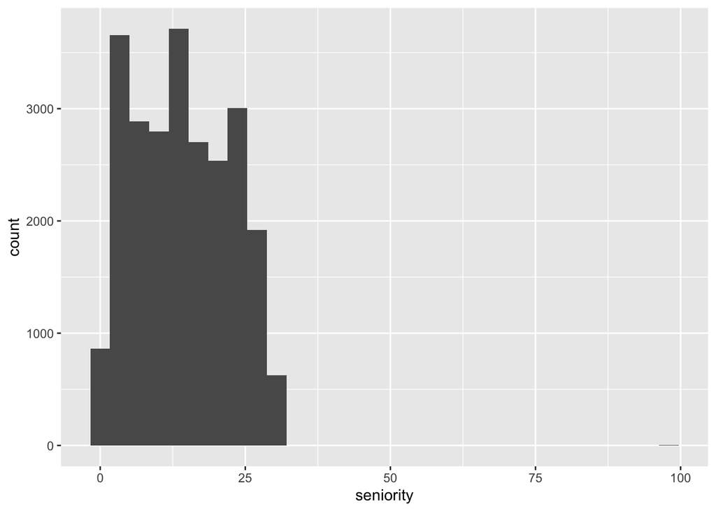

```r
ggplot(df,aes(x=seniority))+
  geom_histogram()
```

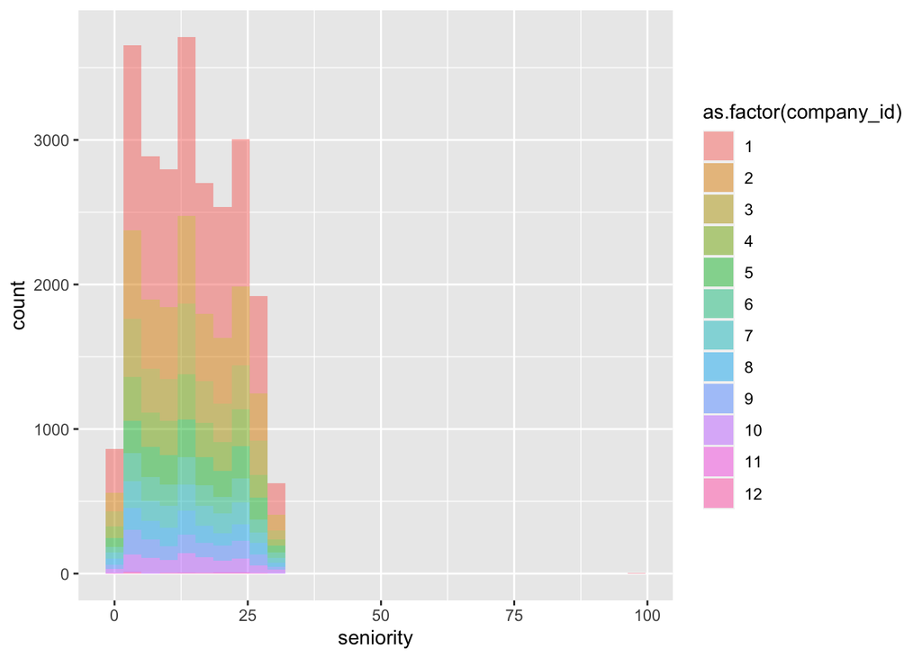

```r
ggplot(df,aes(x=seniority))+
  geom_histogram(aes(fill=as.factor(company_id)),alpha=0.5)
```

```r
#check out the outliers
filter(df,seniority>40)
```

```
##   employee_id company_id      dept seniority salary  join_date  quit_date
## 1       97289         10  engineer        98 266000 2011-12-13 2015-01-09
## 2      604052          1 marketing        99 185000 2011-07-26 2013-12-06
```

```r
#Count the record cases by Company
df%>%
  group_by(company_id)%>%
  summarise(count=n())
```

```
## # A tibble: 12 x 2
##    company_id count
##         <int> <int>
##  1          1  8486
##  2          2  4222
##  3          3  2749
##  4          4  2062
##  5          5  1755
##  6          6  1291
##  7          7  1224
##  8          8  1047
##  9          9   961
## 10         10   865
## 11         11    16
## 12         12    24
```

```r
#Employees from Company 1 take up a large portion of the dataset
```

# Estimating headcount for each company

```r
unique_dates<-seq(as.Date("2011-01-24"),as.Date("2015-12-13"),by="day")
# create list of unique dates for the table

unique_companies<-unique(df$company_id)
#create list of unique companies

data_headcount<-merge(unique_dates,unique_companies,by=NULL)
#cross join so i get all combinations of dates and companies; to assigne a unique date for each company

colnames(data_headcount)<-c("date","company_id")

#now for each day/company, how many people quit/got hired on that day
data_join<-df%>%
  group_by(join_date,company_id)%>%
  summarise(join_count=n())
data_quit<-df%>%
  group_by(quit_date,company_id)%>%
  summarise(quit_count=n())
#Now I left outer join with data_headcount
#NA means no people were hired /quit on that day cause there's no match; two ways to do this with different function

#way 1 using merge
data_headcount1<-merge(data_headcount,data_join,
                       by.x=c("date","company_id"),
                       by.y=c("join_date","company_id"),
                       all.x=TRUE)


data_headcount1<-merge(data_headcount1,data_quit,
                       by.x=c("date","company_id"),
                       by.y=c("quit_date","company_id"),
                       all.x=TRUE)

# way 2 using left_join
data_headcount2<-left_join(data_headcount,data_join,by=c("date"="join_date","company_id"))
data_headcount2<-left_join(data_headcount2,data_quit,by=c("date"="quit_date","company_id"))

#repalce the NAs with 0
data_headcount1$join_count[is.na(data_headcount1$join_count)]<-0
data_headcount1$quit_count[is.na(data_headcount1$quit_count)]<-0

#Now i need the sum by company_id. Data set is alreadt ordered by date,
# so i can simply use dplyr to group by company_id and do cumsum

data_headcount1<-data_headcount1%>%
  group_by(company_id)%>%
  mutate(join_cumsum=cumsum(join_count),
         quit_cumsum=cumsum(quit_count))

#finally for each data i just take join_count - quit_count and i am done data_headcount$
data_headcount1$count<-data_headcount1$join_cumsum-data_headcount1$quit_cumsum

data_headcount_table<-data.frame(data_headcount1[,c("date","company_id","count")])
```

```r
#another way to compute in a for loop (super slow); a one for all means that present a final dataset

loop_cumsum<-c()
loop_date<-c()
loop_company<-c()

for (i in unique_dates) {
  #loop through all days
  for (j in unique(df$company_id)) {
    #loop through all companies
    tmp_join<-nrow(subset(df,join_date<= i & company_id==j)) # count joins until that day
    tmp_quit<-nrow(subset(df,quit_date<=i & company_id==j))  # count quits until that day
    loop_cumsum<-c(loop_cumsum,tmp_join-tmp_quit)
    loop_date<-c(loop_date,i)
    loop_company<-c(loop_company,j)
  }
  data_headcount_table_loop<-data.frame(date=as.Date(loop_date,origin='1970-01-01'),
                                        company_id=loop_company,
                                        count=loop_cumsum)
}

head(data_headcount_table_loop)
```

```
##         date company_id count
## 1 2011-01-24          7     1
## 2 2011-01-24          4    12
## 3 2011-01-24          2    17
## 4 2011-01-24          9     3
## 5 2011-01-24          1    25
## 6 2011-01-24          6     3
```

## What are the main factors that drive employee churn? Do they make sense? Explain the findings.

```r
# How many days was she employed? This should be matter.
# People might get bored in the same place for too long
# Some hunthead offered better offer with regards to salary

df$tenue<-as.numeric(df$quit_date-df$join_date)

# In general, whenever we have a date, we shall extract week of the year, and day of the week. They tend to give an idea of seasonality and weekly trends.
# In this case,weekly trends probably don't matter. So let's just get week of the year (seasonality)

df$week_of_year<-as.numeric(format(df$quit_date,"%U"))  # %G --year
```

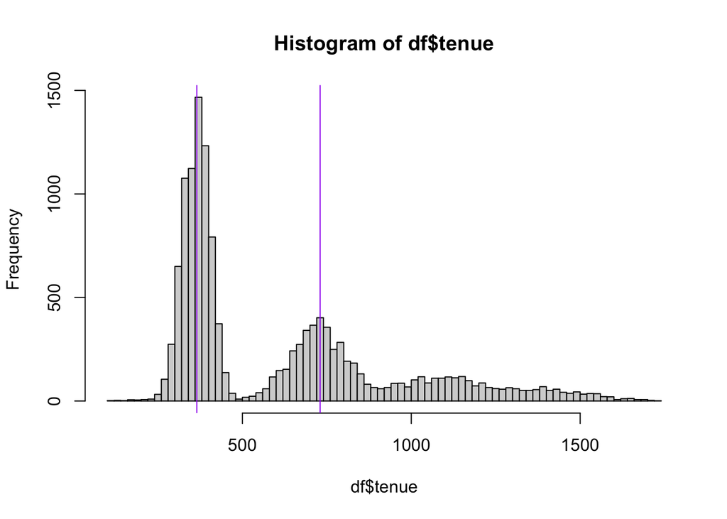

```r
#let's plot the tenure in days
hist(df$tenue,breaks=100)
abline(v=365,col='purple')
abline(v=365*2,col='purple')
```

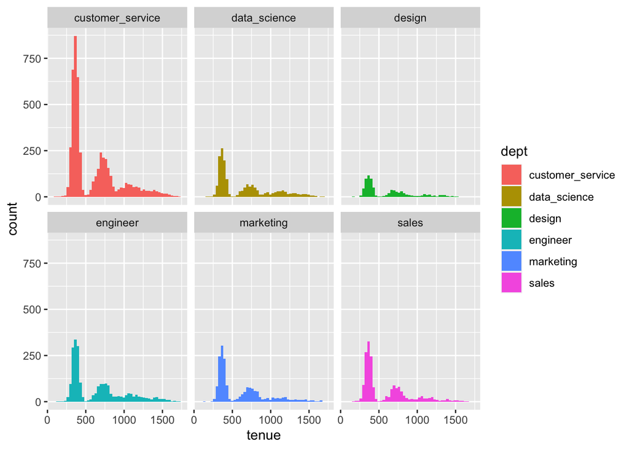

```r
#by department to see if there's group difference
ggplot(df,aes(x=tenue,fill=dept))+
  geom_histogram(bins = 50)+
  facet_wrap(~dept)
```

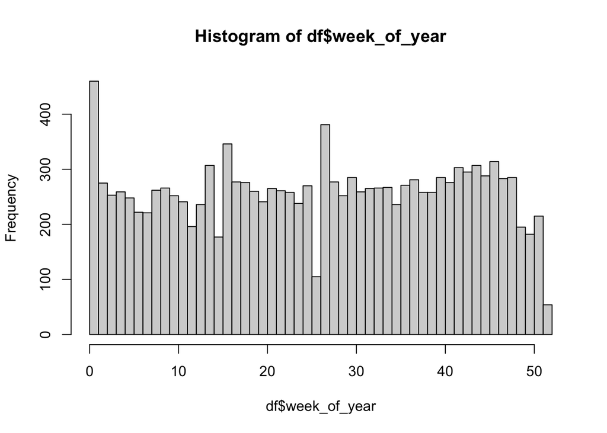

```r
#let's plot seasonal dropout trend of the year
hist(df$week_of_year,breaks=length(unique(df$week_of_year)))
```

1. There are peak dropouts around each employee’s year anniversary, 1st 2nd, after two years the turnover become more random and evenly distributed.

2. According to the quit_week_of_the_year, it also peaks around the beginning of a year. The results quite make sense as companies have so much more money to hire at the beginning of the year. That is, employees left for better salary packages in a new company. We also observe a second peak of turning in the mid of the year, around 26th week.
3. There’s no observable difference between departments in length of employment(tenure).

Now let’s see if we find the characteristics of the people who quit early. Looking at the histogram of tenure, it looks like we could define early quitters as those people who quit within 1 year or so.(majority of the sample)

So let’s create two classes of users: quit within 13 months or not (if they haven’t been in the current company for at least 13 months, we remove them)

```r
#create a binary class, remove those who haven't been in the company for more than 13 months
data<-subset(df,df$join_date< as.Date("2015-12-13")-(365+31))# only keep people who had enough time to age

data$early_quitter<-as.factor(ifelse(is.na(data$quit_date)|as.numeric(data$quit_date-data$join_date)> 396,0,1))
```

Let’s now build a model. Here we can just care about：seniority,salary,department and company. A simple decision tree is probably more than enough

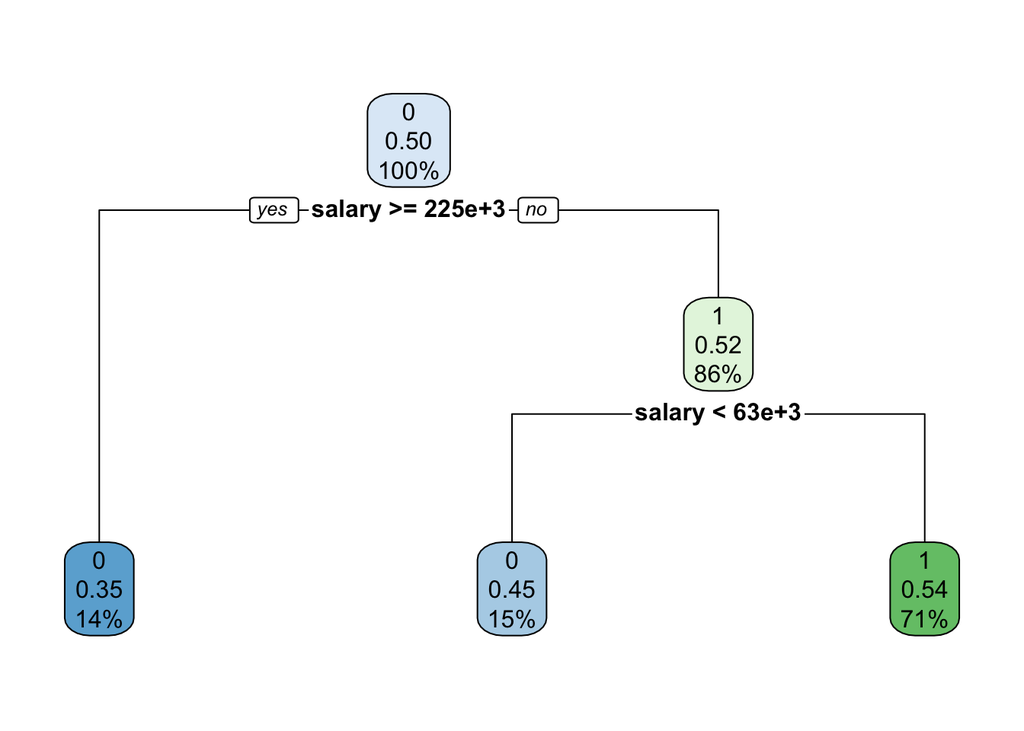

```r
library(rpart.plot)
tree<-rpart(early_quitter~., data[,c("company_id","dept","seniority","early_quitter","salary")],
            control = rpart.control(minbucket = 30,maxdepth = 3, cp=0.000001),
            parms=list(prior=c(0.5,0.5)))

# we are not too interested in predictive power,we are mainly using the tree as a descriptive stat tool
rpart.plot(tree)
```

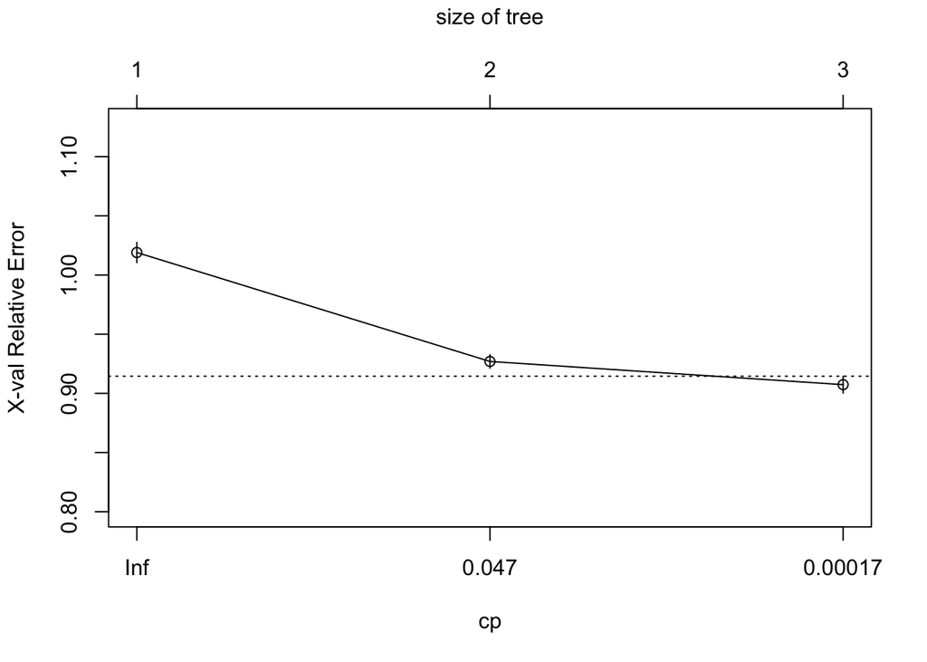

```r
plotcp(tree)
```

```r
summary(tree)
```

```
## Call:
## rpart(formula = early_quitter ~ ., data = data[, c("company_id",
##     "dept", "seniority", "early_quitter", "salary")], parms = list(prior = c(0.5,
##     0.5)), control = rpart.control(minbucket = 30, maxdepth = 3,
##     cp = 1e-06))
##   n= 19270
##
##           CP nsplit rel error    xerror        xstd
## 1 0.07814020      0 1.0000000 1.0190110 0.008501904
## 2 0.02875058      1 0.9218598 0.9269611 0.005709519
## 3 0.00000100      2 0.8931092 0.9073705 0.007126904
##
## Variable importance
##    salary seniority
##        90        10
##
## Node number 1: 19270 observations,    complexity param=0.0781402
##   predicted class=0  expected loss=0.5  P(node) =1
##     class counts: 13480  5790
##    probabilities: 0.500 0.500
##   left son=2 (2764 obs) right son=3 (16506 obs)
##   Primary splits:
##       salary     < 224500 to the right, improve=131.906600, (0 missing)
##       dept       splits as  RLLLRR,     improve= 41.471740, (0 missing)
##       seniority  < 4.5    to the left,  improve= 13.407400, (0 missing)
##       company_id < 2.5    to the left,  improve=  3.270889, (0 missing)
##
## Node number 2: 2764 observations
##   predicted class=0  expected loss=0.347196  P(node) =0.1278438
##     class counts:  2250   514
##    probabilities: 0.653 0.347
##
## Node number 3: 16506 observations,    complexity param=0.02875058
##   predicted class=1  expected loss=0.4776014  P(node) =0.8721562
##     class counts: 11230  5276
##    probabilities: 0.478 0.522
##   left son=6 (2887 obs) right son=7 (13619 obs)
##   Primary splits:
##       salary     < 62500  to the left,  improve=34.755940, (0 missing)
##       seniority  < 4.5    to the left,  improve=30.227760, (0 missing)
##       dept       splits as  LLLLLR,     improve= 4.463953, (0 missing)
##       company_id < 9.5    to the left,  improve= 1.442755, (0 missing)
##   Surrogate splits:
##       seniority < 4.5    to the left,  agree=0.923, adj=0.561, (0 split)
##
## Node number 6: 2887 observations
##   predicted class=0  expected loss=0.4501141  P(node) =0.1440817
##     class counts:  2136   751
##    probabilities: 0.550 0.450
##
## Node number 7: 13619 observations
##   predicted class=1  expected loss=0.4632968  P(node) =0.7280745
##     class counts:  9094  4525
##    probabilities: 0.463 0.537
```

```r
#By plotting the proportion of early quitter by salary percentile, this becomes quite clear:
data$salary_percentile<-cut(data$salary, breaks= quantile(data$salary,probs=seq(0,1,0.01)), include.lowest = TRUE, labels=1:100)

data_proportion_by_percentitle <- data %>%
  group_by(salary_percentile)%>%
  summarize(proportion_early_quitters=length((early_quitter[early_quitter==1])/length(early_quitter)))
```

[output not shown]

[output cut: 244 more lines]

[output not shown]

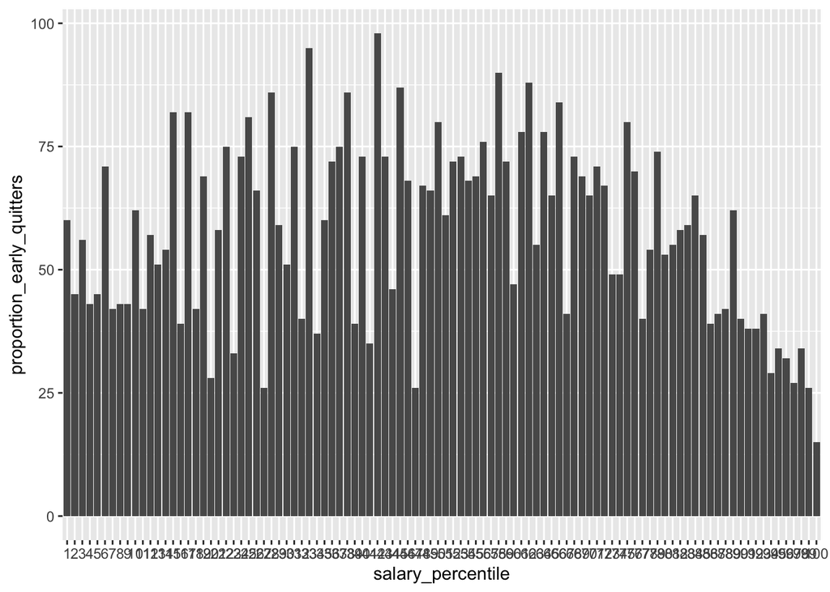

```r
ggplot(data=data_proportion_by_percentitle,aes(x=salary_percentile,y=proportion_early_quitters))+
  geom_col()
```

```r
#calculating the percentile rank
PercentileRank<- function(scores, your_score){
  count <-0
  for (score in scores) {
    if (score <= your_score){
      count<-count+1 }
    else{
      count<-count
    }
  }

  percentile_rank<-100.0 * count / length(scores)
  percentile_rank
}

PercentileRank(data$salary,62500) # 15% percentile
```

```
## [1] 14.98184
```

```r
PercentileRank(data$salary,224500) #86% percentile
```

```
## [1] 85.65646
```

```r
#from the plot we could see for salary percentile fall between 15% and 86%, the count of dropout is high.
```

1. Given how important is salary, i would definitely love to have as a variable the salary the employee who quit was offered in the next job. Otherwise, things like : promotion or raises received during the employee tenure would be interesting.
2. The major findings are that employees quit at year anniversaries or at the beginning of the year. Both cases make sense. Even if you don’t like your current job, you often stay for 1 year before quitting or you often get stocks after 1 year so it makes sense to wait. Besides, the beginning of the year is well known to be the best time to change job: companies are hiring more and you often want to stay until end of Dec to get the annual bonus
3. Employees with low and high salaries are less likely to quit. Probably because employees with high salaries are satisfied with current status and those with low salaries are less marketable, so they would rather be more stable.